# PCIT-CoS-Waitlist RCT Paper 1: TOPSE Emotion

Nancy Briggs

2024-04-29

### TOPSE Emotion

Output run on 2024-04-29

Values have been calculated by: - sum computed from CCQA7, CCQA8, CCQA9, CCQA10, CCQA11, CCQA12_R

#### Descriptives

| group | time | n | mean | sd | median | min | max |
| --- | --- | --- | --- | --- | --- | --- | --- |
| 1 | 1 | 30 | 52.133 | 6.709 | 53.500 | 34 | 60 |
| 1 | 2 | 23 | 55.087 | 5.720 | 58.000 | 41 | 60 |
| 1 | 3 | 18 | 53.889 | 4.324 | 55.000 | 45 | 60 |
| 2 | 1 | 28 | 53.166 | 6.722 | 55.818 | 29 | 60 |
| 2 | 2 | 13 | 51.769 | 5.052 | 52.000 | 43 | 59 |
| 2 | 3 | 5 | 53.200 | 4.087 | 52.000 | 49 | 58 |
| 3 | 1 | 26 | 54.423 | 4.876 | 56.000 | 45 | 60 |
| 3 | 2 | 22 | 53.727 | 4.188 | 54.500 | 46 | 60 |
| 3 | 3 | 0 | NaN | NA | NA | Inf | -Inf |

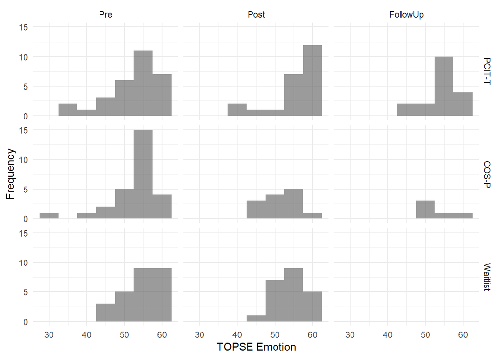

#### Model & Results

A linear mixed model with random effect for individual and fixed effects of group, time and the interaction was run. Estimated marginal means were obtained, and contrasts specified to test Hypothesis 1 and Hypothesis 2.

```
## fixed-effect model matrix is rank deficient so dropping 1 column / coefficient
```

```
## refitting model(s) with ML (instead of REML)
```

|  | Effect | npar | AIC | BIC | logLik | deviance | Chisq | Df | Pr(>Chisq) |
| --- | --- | --- | --- | --- | --- | --- | --- | --- | --- |
| result0 | Intercept | 3 | 1024.661 | 1033.979 | -509.331 | 1018.661 | NA | NA | NA |
| result1 | Group | 5 | 1027.616 | 1043.146 | -508.808 | 1017.616 | 1.045 | 2 | 0.593 |
| result2 | Time | 7 | 1029.938 | 1051.680 | -507.969 | 1015.938 | 1.678 | 2 | 0.432 |
| result3 | Group*Time | 10 | 1028.955 | 1060.014 | -504.478 | 1008.955 | 6.983 | 3 | 0.072 |

This is the ANOVA table for the model. p-values are likelihood ratio tests for adding the new term to the model just before. A p-value <0.05 indicates that adding that term results in better model fit. The most important p-value is the interaction p-value. Here, there is no evidence that the pattern of change over time is different among the groups (p=0.072).

```r
summary(result3)
```

```
## Linear mixed model fit by REML. t-tests use Satterthwaite's method [
## lmerModLmerTest]
## Formula: outcome ~ group * time + (1 | id)
##    Data: dat
##
## REML criterion at convergence: 991.5
##
## Scaled residuals:
##     Min      1Q  Median      3Q     Max
## -3.6212 -0.2777  0.1866  0.5038  1.9032
##
## Random effects:
##  Groups   Name        Variance Std.Dev.
##  id       (Intercept) 14.36    3.79
##  Residual             17.22    4.15
## Number of obs: 165, groups:  id, 85
##
## Fixed effects:
##              Estimate Std. Error      df t value Pr(>|t|)
## (Intercept)    52.133      1.026 125.548  50.807   <2e-16 ***
## group2          1.032      1.477 125.548   0.699   0.4859
## group3          2.379      1.503 127.081   1.583   0.1159
## time2           3.072      1.182  81.668   2.598   0.0111 *
## time3           2.564      1.293  84.560   1.983   0.0506 .
## group2:time2   -4.288      1.913  90.672  -2.241   0.0274 *
## group3:time2   -3.704      1.711  82.136  -2.164   0.0333 *
## group2:time3   -2.493      2.592  95.017  -0.962   0.3385
## ---
## Signif. codes:  0 '***' 0.001 '**' 0.01 '*' 0.05 '.' 0.1 ' ' 1
##
## Correlation of Fixed Effects:
##             (Intr) group2 group3 time2  time3  grp2:2 grp3:2
## group2      -0.695
## group3      -0.683  0.474
## time2       -0.473  0.329  0.323
## time3       -0.433  0.301  0.295  0.415
## group2:tim2  0.292 -0.421 -0.200 -0.618 -0.257
## group3:tim2  0.327 -0.227 -0.487 -0.691 -0.287  0.427
## group2:tim3  0.216 -0.311 -0.147 -0.207 -0.499  0.317  0.143
## fit warnings:
## fixed-effect model matrix is rank deficient so dropping 1 column / coefficient
```

#### Estimated Means & Change

Estimated means for each Treatment and Time are presented. In addition, within-group change between time points is presented with 95% CIs.

##### Group mean difference at each timepoint

NOTE THIS SET OF RESULTS DOES NOT BOOTSTRAP.

Effect sizes all calculated by the pooled T1 SD of the outcome. Adjusted p-value from Bonferroni correction.

Group Differences at Each Time Point

| Group Difference | Time | Mean | SE | t | p | adj p | Lower CL | Upper CL | Effect Size | Lower CL | Upper CL |
| --- | --- | --- | --- | --- | --- | --- | --- | --- | --- | --- | --- |
| 1 - 2 | 1 | -1.032 | 1.477 | -0.699 | 0.765 | 1.000 | -4.534 | 2.470 | -0.154 | -0.566 | 0.370 |
| 1 - 3 | 1 | -2.379 | 1.503 | -1.583 | 0.257 | 0.348 | -5.943 | 1.185 | -0.354 | -0.719 | -0.069 |
| 2 - 3 | 1 | -1.347 | 1.528 | -0.882 | 0.653 | 1.000 | -4.970 | 2.276 | -0.201 | -0.508 | 0.033 |
| 1 - 2 | 2 | 3.256 | 1.868 | 1.743 | 0.193 | 0.250 | -1.165 | 7.678 | 0.485 | 0.125 | 0.758 |
| 1 - 3 | 2 | 1.325 | 1.641 | 0.807 | 0.699 | 1.000 | -2.562 | 5.212 | 0.197 | -0.420 | 0.598 |
| 2 - 3 | 2 | -1.932 | 1.889 | -1.023 | 0.564 | 0.924 | -6.402 | 2.539 | -0.288 | -1.049 | 0.124 |
| 1 - 2 | 3 | 1.461 | 2.568 | 0.569 | 0.837 | 1.000 | -4.619 | 7.541 | 0.218 | -0.178 | 0.862 |
| 1 - 3 | 3 | NA | NA | NA | NA | NA | NA | NA | NA | NA | NA |
| 2 - 3 | 3 | NA | NA | NA | NA | NA | NA | NA | NA | NA | NA |

##### Change within each group

Within-Group Change and Effect Sizes

| Change | Group | Mean | SE | t | p | adj p | Lower CL | Upper CL | Effect Size | Lower CL | Upper CL |
| --- | --- | --- | --- | --- | --- | --- | --- | --- | --- | --- | --- |
| 1 - 2 | 1 | -3.072 | 1.185 | -2.594 | 0.030 | 0.034 | -5.898 | -0.247 | -0.457 | -0.603 | -0.150 |
| 1 - 3 | 1 | -2.564 | 1.296 | -1.977 | 0.124 | 0.153 | -5.655 | 0.527 | -0.382 | -0.647 | -0.054 |
| 2 - 3 | 1 | 0.509 | 1.344 | 0.379 | 0.924 | 1.000 | -2.698 | 3.716 | 0.076 | -0.460 | 0.201 |
| 1 - 2 | 2 | 1.216 | 1.512 | 0.805 | 0.701 | 1.000 | -2.380 | 4.813 | 0.181 | -0.284 | 0.678 |
| 1 - 3 | 2 | -0.070 | 2.261 | -0.031 | 0.999 | 1.000 | -5.447 | 5.307 | -0.010 | -0.548 | 0.698 |
| 2 - 3 | 2 | -1.287 | 2.340 | -0.550 | 0.847 | 1.000 | -6.863 | 4.290 | -0.192 | -0.822 | 0.371 |
| 1 - 2 | 3 | 0.632 | 1.239 | 0.510 | 0.867 | 1.000 | -2.324 | 3.588 | 0.094 | -0.320 | 0.572 |
| 1 - 3 | 3 | NA | NA | NA | NA | NA | NA | NA | NA | NA | NA |
| 2 - 3 | 3 | NA | NA | NA | NA | NA | NA | NA | NA | NA | NA |

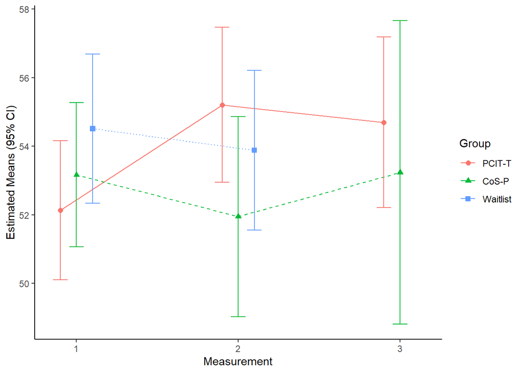

#### Hypothesis 1

We hypothesize that from baseline (‘T1’) to post-treatment/waitlist (‘T2’) there will be a gradient effect, whereby parent-child dyads who receive PCIT-T will show the greatest gains and parent-child dyads who receive no treatment will show the least gains. For the outcome, then, the null hypothesis is:

$H_0: \text {mean change}(\text{PCIT-T}) = \text {mean change}(\text{CoS-P}) = \text {mean change}(\text{Waitlist})$ $H_A: \text {mean change}(\text{PCIT-T}) > \text {mean change}(\text{CoS-P}) > \text {mean change}(\text{Waitlist})$

This is a joint hypothesis test.

```
## group = 1:
##  contrast estimate   SE    df t.ratio p.value
##  1 - 2     -3.0723 1.18  84.8  -2.594  0.0298
##  1 - 3     -2.5636 1.30  87.7  -1.977  0.1238
##  2 - 3      0.5088 1.34  82.6   0.379  0.9241
##
## group = 2:
##  contrast estimate   SE    df t.ratio p.value
##  1 - 2      1.2161 1.51  99.6   0.805  0.7011
##  1 - 3     -0.0704 2.26 101.6  -0.031  0.9995
##  2 - 3     -1.2865 2.34  89.9  -0.550  0.8468
##
## group = 3:
##  contrast estimate   SE    df t.ratio p.value
##  1 - 2      0.6316 1.24  85.7   0.510  0.8669
##  1 - 3      nonEst   NA    NA      NA      NA
##  2 - 3      nonEst   NA    NA      NA      NA
##
## Degrees-of-freedom method: kenward-roger
## P value adjustment: tukey method for comparing a family of 3 estimates
```

Now, to get the p-value associated with the joint hypothesis.

```
##   (Intercept) group2 group3 time2 time3 group2:time2 group3:time2 group2:time3
## 1           0      0      0     0     0           -1            0            0
## 2           0      0      0     0     1            0            1            0
```

```
##
##   General Linear Hypotheses
##
## Linear Hypotheses:
##        Estimate
## 1 == 0    4.288
## 2 == 0   -1.140
##
## Global Test:
##       F DF1 DF2  Pr(>F)
## 1 2.521   2 155 0.08364
```

#### Hypothesis 2

##### Change from T2-T3

There will be a gradient of size of change from T2 to T3 such that the change in the PCIT-T group > the change in the CoS-P group. This isn’t really a gradient; it’s just 1 hypothesis.

First, the change in PCITT and COSP from time 2 to time 3:

```
## group = 1:
##  time emmean   SE  df lower.CL upper.CL
##  1      52.1 1.03 128     50.1     54.2
##  2      55.2 1.14 145     52.9     57.5
##  3      54.7 1.26 155     52.2     57.2
##
## group = 2:
##  time emmean   SE  df lower.CL upper.CL
##  1      53.2 1.06 128     51.1     55.3
##  2      51.9 1.48 157     49.0     54.9
##  3      53.2 2.24 136     48.8     57.7
##
## group = 3:
##  time emmean   SE  df lower.CL upper.CL
##  1      54.5 1.10 130     52.3     56.7
##  2      53.9 1.18 141     51.6     56.2
##  3    nonEst   NA  NA       NA       NA
##
## Degrees-of-freedom method: kenward-roger
## Confidence level used: 0.95
```

```
## group = 1:
##  contrast estimate   SE    df lower.CL upper.CL
##  1 - 2     -3.0723 1.18  84.8    -5.90   -0.247
##  1 - 3     -2.5636 1.30  87.7    -5.65    0.527
##  2 - 3      0.5088 1.34  82.6    -2.70    3.716
##
## group = 2:
##  contrast estimate   SE    df lower.CL upper.CL
##  1 - 2      1.2161 1.51  99.6    -2.38    4.813
##  1 - 3     -0.0704 2.26 101.6    -5.45    5.307
##  2 - 3     -1.2865 2.34  89.9    -6.86    4.290
##
## group = 3:
##  contrast estimate   SE    df lower.CL upper.CL
##  1 - 2      0.6316 1.24  85.7    -2.32    3.588
##  1 - 3      nonEst   NA    NA       NA       NA
##  2 - 3      nonEst   NA    NA       NA       NA
##
## Degrees-of-freedom method: kenward-roger
## Confidence level used: 0.95
## Conf-level adjustment: tukey method for comparing a family of 3 estimates
```

```r
## Specify contrast matrices
# Hyp1 is 1 df test
# could use alternative="less" ir alternative="greater" in glht
hyp2   <- matrix(c(0, 0,0, 0,0, -1,0,1 ),1)
hyp2F <- glht(result3, linfct = hyp2)
summary(hyp2F)
```

```
##
##   Simultaneous Tests for General Linear Hypotheses
##
## Fit: lmer(formula = outcome ~ group * time + (1 | id), data = dat)
##
## Linear Hypotheses:
##        Estimate Std. Error z value Pr(>|z|)
## 1 == 0    1.795      2.689   0.668    0.504
## (Adjusted p values reported -- single-step method)
```

```r
s<-summary(hyp2F, test = Ftest())
#also see this webpage for more on contrasts https://rcompanion.org/rcompanion/h_01.html



## Extract pvaue for evidence / no evidence
evidence = ifelse(s$test$pvalue<0.05, "evidence", "no evidence")
```

Change in G1 from T2 to T3: 0.509

Change in G2 from T2 to T3: -1.287

##### Change from T1-T3

```
##
##   General Linear Hypotheses
##
## Linear Hypotheses:
##        Estimate
## 1 == 0   -2.493
##
## Global Test:
##        F DF1 DF2 Pr(>F)
## 1 0.9254   1 155 0.3375
```

Change in G1 from T1 to T3: -2.564

Change in G2 from T1 to T3: -0.07

p=0.3375. We have no evidence that the change from T1 to T3 is different for G1 and G2

#### Residuals

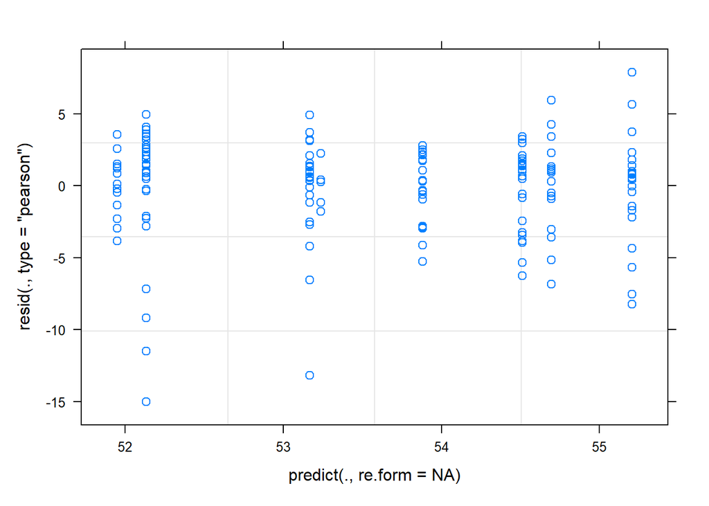

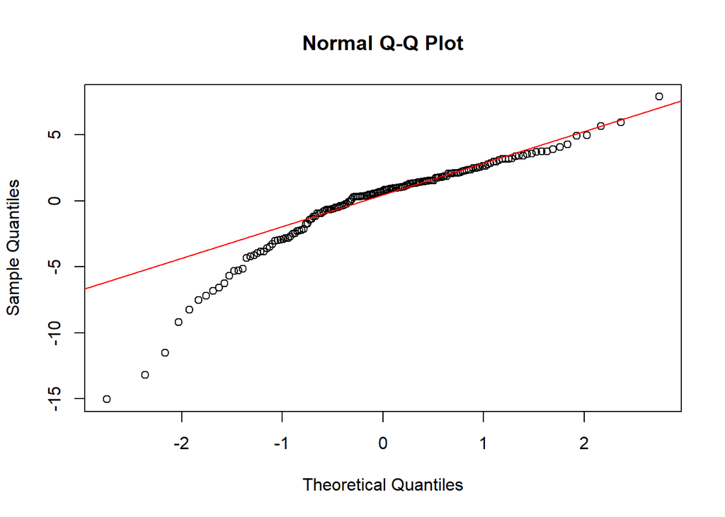

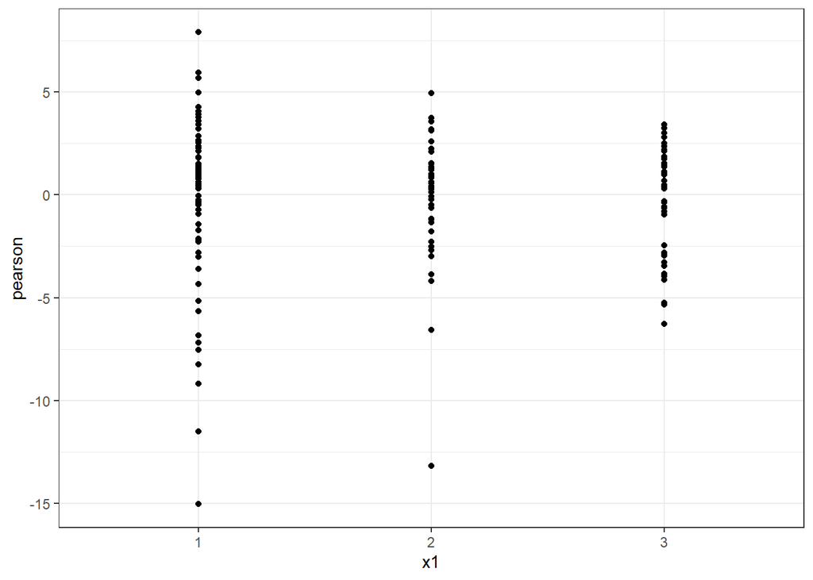

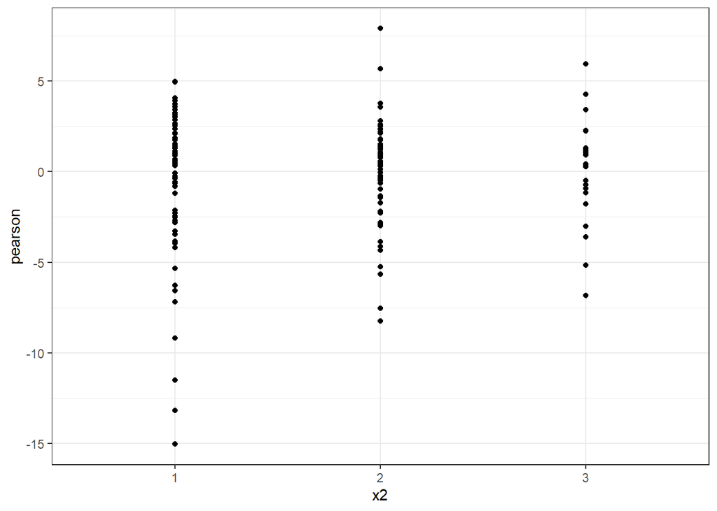

```r
rm(list = ls())
```